# Logistic regression: Part II

```r
library(ggplot2)
library(dplyr)
```

**Logistic Regression**

Let $y$ be a binary categorical response variable:
$$y =
\begin{cases}
1 & \; \text{ if event happens} \\
0 & \; \text{ if event doesn't happen} \\
\end{cases}$$

Further define

$$\begin{split}
p &= \text{ probability event happens} \\
1-p &= \text{ probability event doesn't happen} \\
\text{odds} & = \text{ odds event happens} = \frac{p}{1-p} \\
\end{split}$$

Then a logistic regression model of $y$ by $x$ is
$$\log(\text{odds}) = \beta_0 + \beta_1 x$$

We can transform this to get (curved) models of odds and probability:

$$\begin{split}
\text{odds} & = e^{\beta_0 + \beta_1 x} \\
p & = \frac{\text{odds}}{\text{odds}+1} = \frac{e^{\beta_0 + \beta_1 x}}{e^{\beta_0 + \beta_1 x}+1} \\
\end{split}$$

**Coefficient interpretation for quantitative x**
$$\begin{split}
\beta_0 & = \text{ LOG(ODDS) when } x=0 \\
e^{\beta_0} & = \text{ ODDS when } x=0 \\
\beta_1 & = \text{ unit change in LOG(ODDS) per 1 unit increase in } x \\
e^{\beta_1} & = \text{ multiplicative change in ODDS per 1 unit increase in } x \text{ (ie. the odds ratio)} \\
\end{split}$$

**Coefficient interpretation for categorical x**
$$\begin{split}
\beta_0 & = \text{ LOG(ODDS) at the reference category } \\
e^{\beta_0} & = \text{ ODDS at the reference category } \\
\beta_1 & = \text{ unit change in LOG(ODDS) relative to the reference} \\
e^{\beta_1} & = \text{ multiplicative change in ODDS relative to the reference } \text{ (ie. the odds ratio)} \\
\end{split}$$

**Interpreting odds ratios**

If $e^{\beta_1} = 2$:

- the odds *double* when we increase x by 1
- the odds are twice as big when we increase x by 1

If $e^{\beta_1} = 0.5$:

- the odds *cut in half* when we increase x by 1
- the odds are half (50%) as big when we increase x by 1

# Exercises

Load the climbers data:

```r
climbers_sub <- read.csv("https://www.macalester.edu/~ajohns24/data/climbers_sub.csv") %>%
  select(peak_name, success, age, oxygen_used, year)
```

In yesterday’s activity, we modeled climber `success`. Today we’ll consider some more models:

## Exercise 1: Hello!

How do you plan to make wellness day a true wellness day?

$$\mathcal{Dune} \text{ and } \texttt{Haskell}$$

## Exercise 2: Normal or logistic?

For each scenario below, indicate whether Normal or logistic regression would be the appropriate modeling tool.

1. We want to model whether or not a person believes in climate change (y) based on their age (x). **logistic**
2. We want to model whether or not a person believes in climate change (y) based on their location (x). **logistic**
3. We want to model a person’s reaction time (y) by how long they slept the night before (x). **normal**
4. We want to model a person’s reaction time (y) by whether or not they took a nap today (x). **normal**

## Exercise 3: `climb_model_1`: `success` vs `year`

1. With a goal of understanding how climbing success rates have changed over time, model `success` by `year`.

```r
climb_model_1 <- glm(success ~ year, climbers_sub, family = "binomial")
summary(climb_model_1)$coefficients
```

```
##                  Estimate  Std. Error   z value     Pr(>|z|)
## (Intercept) -119.36214950 9.560766495 -12.48458 9.062082e-36
## year           0.05934127 0.004768784  12.44369 1.513454e-35
```

2. Write out the model formula and interpret both model coefficients on the *odds* scale.
   $$\log(success) = -119.3621 + 0.05934 year$$
3. Both “by hand” and using the `predict()` function, predict the probability of success for a climber on a 2022 expedition. NOTE: Given the large scale of year, you could get very different answers depending upon how much you round your coefficients (round as little as possible).

```r
v <- -119.3621 + 0.05934 * 2022
exp(v) / (1 + exp(v))
```

```
## [1] 0.6509869
```

```r
predict(climb_model_1, newdata = data.frame(year = 2022))
```

```
##         1
## 0.6259018
```

4. Bonus: plot the model on the probability scale.

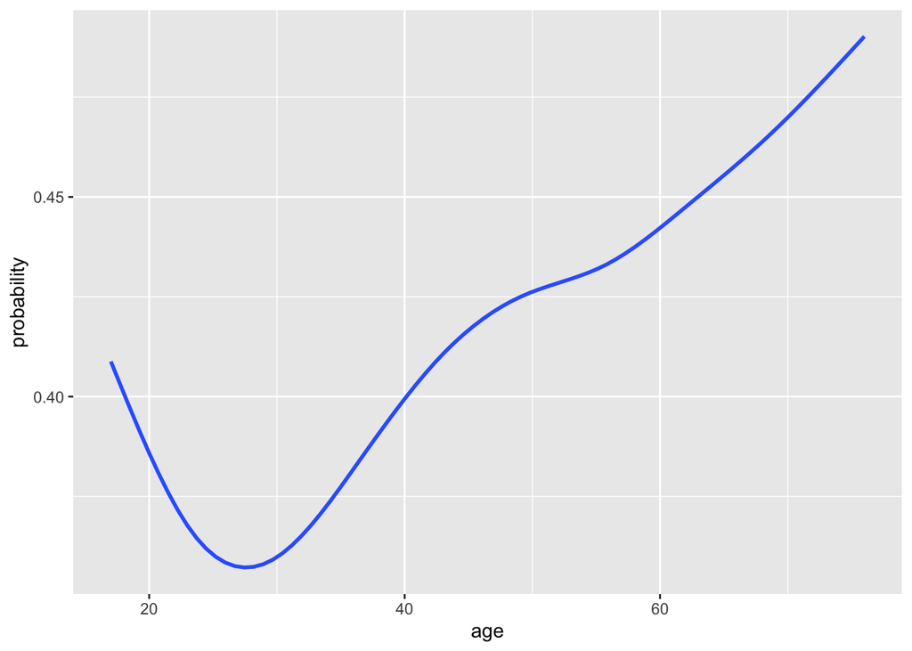

```r
climbers_predictions <- climbers_sub %>%
  mutate(probability = climb_model_1$fitted.values) %>%
  mutate(odds = probability / (1-probability)) %>%
  mutate(log_odds = log(odds))

ggplot(climbers_predictions, aes(x = age, y = probability)) +
  geom_smooth(se = FALSE)
```

## Exercise 4: `climb_model_2`: `success` vs `oxygen_used`

In this exercise you’ll explore the relationship between `success` and the categorical `oxygen_used` predictor:

```r
climb_model_2 <- glm(success ~ oxygen_used, climbers_sub, family = "binomial")
summary(climb_model_2)$coef
```

```
##                  Estimate Std. Error   z value      Pr(>|z|)
## (Intercept)     -1.327993  0.0639834 -20.75528  1.098514e-95
## oxygen_usedTRUE  2.903864  0.1257404  23.09412 5.304291e-118
```

1. Check out and summarize some plots.

   ```r
   # HINT CODE: rewrite in the chunk below
   # A plot of oxygen_used alone
   ggplot(climbers_sub, aes(x = ___)) +
     geom____()

   # A plot of oxygen_used and success
   # (Use the same code as above, other than the fill)
   ggplot(climbers_sub, aes(x = ___, fill = ___)) +
     geom____()
   ```

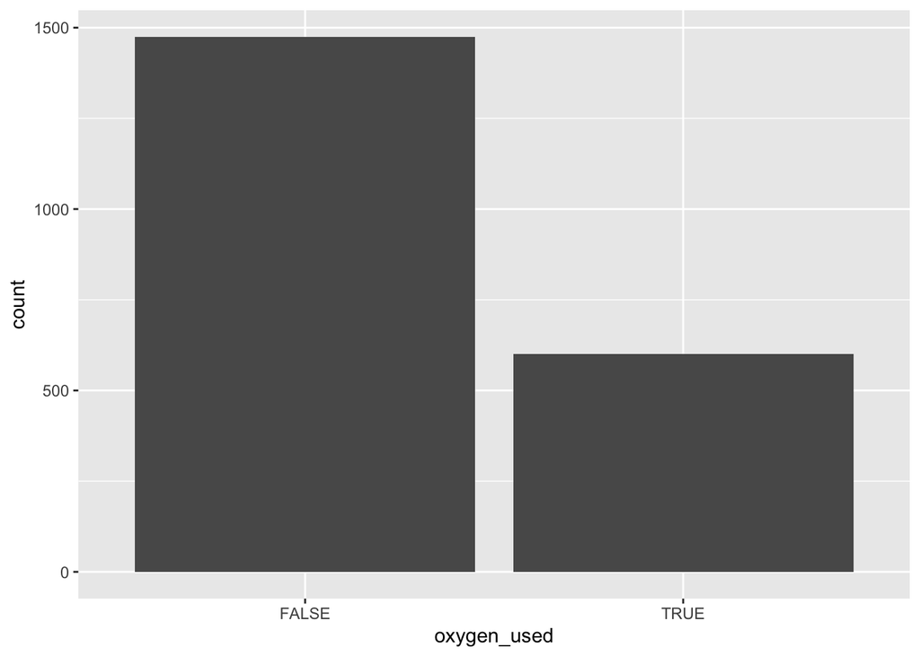

```r
ggplot(climbers_sub, aes(x = oxygen_used)) +
  geom_bar()
```

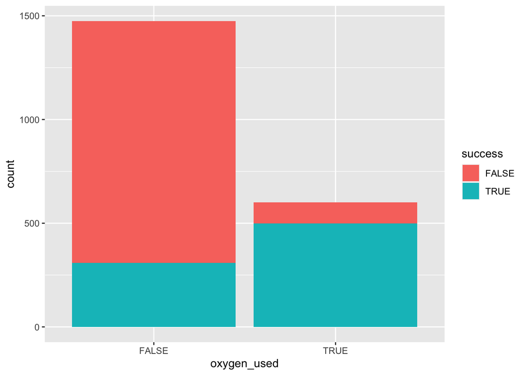

```r
# A plot of oxygen_used and success
# (Use the same code as above, other than the fill)
ggplot(climbers_sub, aes(x = oxygen_used, fill = success)) +
  geom_bar()
```

2. Predict the odds *and* probability of success for a climber that doesn’t use oxygen.

```r
l_odds <- predict(climb_model_2, newdata = data.frame(oxygen_used = FALSE))
odds <- exp(l_odds)
odds
```

```
##         1
## 0.2650086
```

```r
prob <- odds / (1 + odds)
prob
```

```
##         1
## 0.2094915
```

3. Predict the odds *and* probability of success for a climber that does use oxygen.

```r
l_odds <- predict(climb_model_2, newdata = data.frame(oxygen_used = TRUE))
odds_W_O2 <- exp(l_odds)
odds_W_O2
```

```
##        1
## 4.834951
```

```r
prob <- odds_W_O2 / (1 + odds_W_O2)
prob
```

```
##        1
## 0.828619
```

4. Calculate and interpret the following odds ratio: the odds of success for a climber that does use oxygen divided by the odds of success for a climber that doesn’t use oxygen. Eg: By what degree do the odds increase?

```r
ratio <- odds_W_O2 / odds
ratio
```

```
##        1
## 18.24451
```

Your odds increase roughly 18 times having used oxygen.

## Exercise 5: Interpretation

1. On the odds scale, interpret the intercept coefficient from `climb_model_2`. HINT: exp(-1.328)

```r
exp(-1.328)
```

```
## [1] 0.2650067
```

The starting odds at not using oxygen are 0.266.

2. On the odds scale, interpret the `oxygen_usedTRUE` coefficient. HINT: exp(2.904)

```r
exp(2.904)
```

```
## [1] 18.24699
```

The improvement in odds having used oxygen are about 18-fold.

3. Where have you seen the number in part b before?!

The odds ratio!

## Exercise 6: `climb_model_3`: `success` vs `age` and `oxygen_used`

Just as with Normal regression, we can utilize more than 1 predictor in a logistic regression model. Let’s try it!

```r
climb_model_3 <- glm(success ~ age + oxygen_used, climbers_sub, family = "binomial")
summary(climb_model_3)$coef
```

```
##                    Estimate  Std. Error   z value      Pr(>|z|)
## (Intercept)     -0.51957247 0.207331212 -2.506002  1.221049e-02
## age             -0.02197407 0.005459778 -4.024718  5.704361e-05
## oxygen_usedTRUE  2.89559690 0.126370801 22.913496 3.408591e-116
```

1. Construct and summarize a plot of this model on the probability scale:

   ```r
   # HINT CODE
   ggplot(___, aes(x = ___, color = ___, y = as.numeric(success))) +
     geom_smooth(method = "glm", method.args = list(family = "binomial"), se = FALSE, fullrange = TRUE) +
     labs(y = "probability of success")

   # Just for fun zoom out!
   ggplot(___, aes(x = ___, color = ___, y = as.numeric(success))) +
     geom_smooth(method = "glm", method.args = list(family = "binomial"), se = FALSE, fullrange = TRUE) +
     labs(y = "probability of success") +
     lims(x = c(-300, 400))
   ```

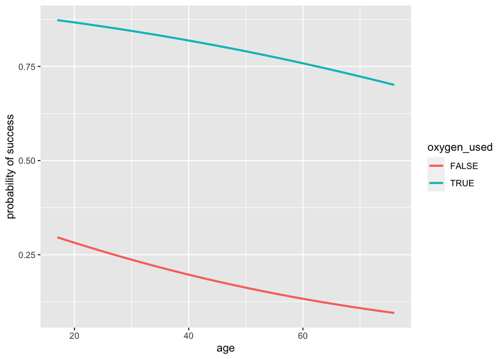

```r
ggplot(climb_model_3, aes(x = age, color = oxygen_used, y = as.numeric(success))) +
  geom_smooth(method = "glm", method.args = list(family = "binomial"), se = FALSE, fullrange = TRUE) +
  labs(y = "probability of success")
```

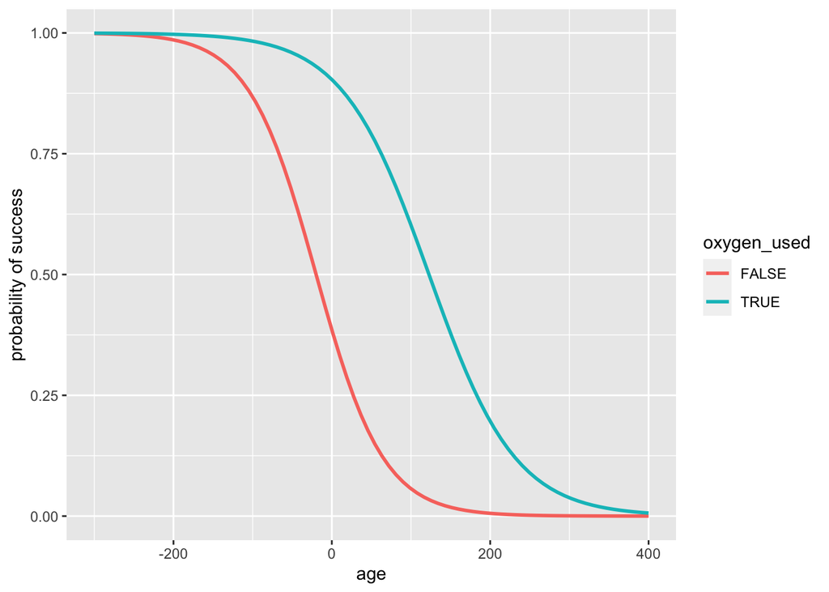

```r
ggplot(climb_model_3, aes(x = age, color = oxygen_used, y = as.numeric(success))) +
  geom_smooth(method = "glm", method.args = list(family = "binomial"), se = FALSE, fullrange = TRUE) +
  labs(y = "probability of success") +
  lims(x = c(-300, 400))
```

2. Interpret the 2 non-intercepts coefficients on the odds scale. Don’t forget to “control for…”!

```r
exp(-0.51957247) # intercept
```

```
## [1] 0.5947748
```

```r
exp(-0.02197407) # age coeff
```

```
## [1] 0.9782656
```

```r
exp(2.89559690) # o2
```

```
## [1] 18.0943
```

Controlling for age, the odds intercept without oxygen is roughly 0.6. Likewise, each year older one is, one’s odds decrease by approximately 2.2%, and using oxygen multiplies one’s changes by about 18.1.

## Exercise 7: Homework 4 + Wrapping Up

If you finish early, please check out the logistic regression exercises in Homework 4. And as always, don’t forget to knit and save your work today :)